# Measuring Apical Constriction

David Kleinhans

2017-11-12

# 1 Rationale

## 1.1 Apical Constriction

During development cells differentiate and undergo drastic shape changes from one morphological typus to another, a process commonly known as morphogenesis. Collective cellular morphologies give rise to tissue morphology, which gives rise to organ morphology and so on. One distinct morphogenetic feature is apical constriction (AC), an active narrowing of cellular apices. Apical constriction occurs in all multicellular organisms and most often during early embryogenesis<sup>1</sup> e.g. during…

- *C.elegans* gastrulation<sup>2</sup>
- *D.Melanogaster* & Vertebrate neural tube formation
- Epithelial-to-mesenchymal transition and ingression

A principal definition is given by J.y. Lee and R.M.Harland<sup>2</sup> and illustrated in figure 1.

> *Apical constriction is the process in which contraction of the apical side of a cell causes the cell to take on a wedged shape. Generally, this shape change is coordinated across many cells of an epithelial layer, generating forces that can bend or fold the cell sheet.*

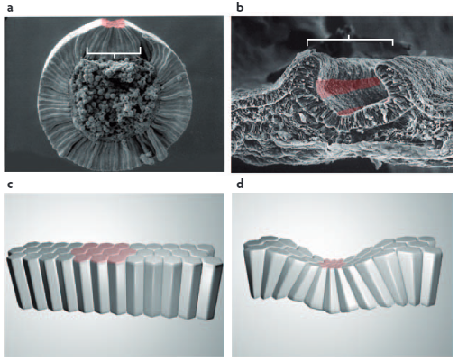

**Figure 1:** Apical constriction and tissue bending. **A** *D. Melanogaster* Mesoderm invagination. **B** Vertebrate neurulation. **C and D** schematic representation of AC in an epithelial tissue<sup>3</sup>.

## 1.2 Measuring AC

### 1.2.1 Parameter definition

To obtain a precise and biologically meaningful quantity for AC, a couple of parameter definitions have to be made…

1. AC is independent of orientation and polarization
   - Cells can be *dorso-ventral* (DV) polarized
   - Cells can also be *cranial-caudal* (CC) polarized
2. AC is independent of lateral height
   - Lateral height can be described as the distance of the two farthest points of the surface area of a cell
   - Two cells with different lateral heights can be equally apically constricted
3. AC is independent of cell volume / size
   - The size of a cell is its volume
   - Two cells of different volume can be equally apically constricted

### 1.2.2 Apical Constriction Index

The earliest attempt found for indexing AC can be found in a study published by Lee *et al.*<sup>4</sup> where they were were looking for the ‘apical index’(A.I.) of bottle cells during xenopus gastrulation.

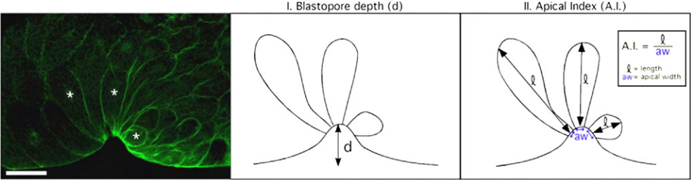

**Figure 2:** Apical Index of Xenopus bottle cells

An application for the apical constriction index (ACI) for the cells in the lateral line primordium was in a study from 2012 where it was shown that Fgfr-Ras-MAPK signaling is required for AC and Rock2a localization<sup>5,6</sup>.

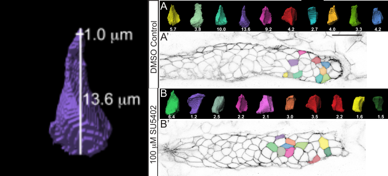

**Figure 3:** Apical constriction index. **(A)** 3D reconstructed cells of a DMSO control primordium and **(B)** 3D reconstructed cells of a primordium deficient of Fgf signaling.

The calculation for the ACI used in 6 does not differ from the A.I. used in 4 and describes the ratio for lateral height over apical width.

$$ACI = \frac{lateral\;height}{apical\;width}$$

While trying to reproduce these results we figured two principal weaknesses of applying this measurement to the cells of the lateral line primordium. One, it does not respect that apical constriction is independent of lateral height. Second, it does not differenciate between *dorso-ventral* and *cranial-caudal* tissue polarization.

#### 1.2.2.1 Adaption for lateral height

Increasing or decreasing cell size should not change for how much a cell is apically constricted.

If $\Delta$ap is a constant, the ACI in a symmetrically enlarged cell increases from e.g. 15 to 23 (Fig.3b ) since apical width stays the same but lateral height increases. On the contrary, if $\Delta$ap changes relative to a cells lateral height, e.g. by percentage (10% - 20%), the ACI in a symmetrically enlarged cell stays the same (Fig.3C).

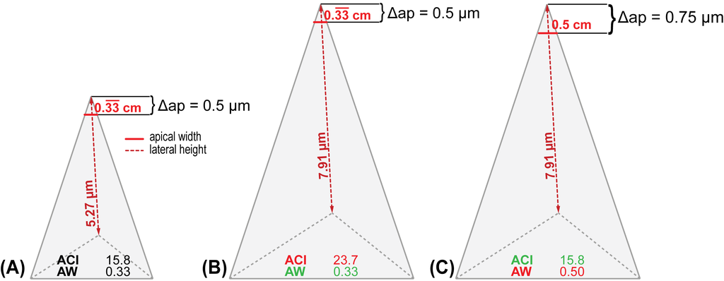

**Figure 3:** ACI Cell Models. **B** and **C** show cells that are symmetrically increased versions of **A**. While in **B**, the same $\Delta$ap was used than in **A**, in **C** $\Delta$ap was adjusted proportional to the lateral height.

$$ACI = \frac{relative\;lateral\;height}{apical\;width}$$

#### 1.2.2.2 Adaption for polarization

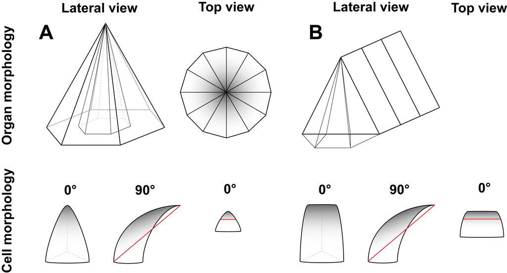

1. $$ACI_W = \frac{relative\;lateral\;height}{apical\;width}$$
2. $$ACI_H = \frac{relative\;lateral\;height}{apical\;height}$$
3. $$ACI = \frac{ACI_W}{ACI_H}$$

# 2 Image Analysis

For image analysis a custom imagej macro was written that first registers the PLLp and aligns it, then the cells are segmented in 3D and different quantitative features are extracted.

## 2.1 Image data

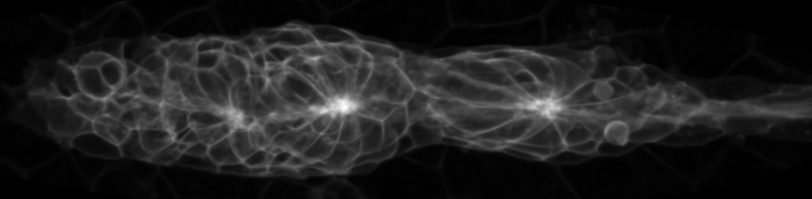

DMSO Control

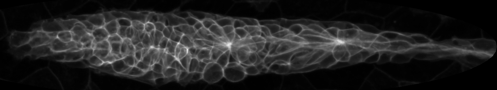

SU5402

## 2.2 Algorithm scheme

# 3 Data Processing

## 3.1 Data import

List files

[figure not shown]

```r
knitr::include_graphics("D:/David/RNotes/171105_ACI/Apical Constriction2.png")
```

Define function to import and process data

```r
library(plyr)
library(dplyr)
read.data.all.3D <- function(file){
    dat <- read.table(file, sep="\t", header=TRUE)
    dat$Nb <- NULL
    dat$Obj <- file
    dat$X <- NULL
    Zcal <- dat$CZ..unit./dat$CZ..pix.                # To transform pix to unit value in Z
    XYcal <- dat$CX..unit./dat$CX..pix.               # To transform pix to unit value in X and Y
    dat$Height <- (dat$Zmax..pix.-dat$Zmin..pix.)*Zcal  # calculate Height and transform to unit value
    dat$Height <- dat$Height*Zcal                       # calculate Height and transform to unit value
    dat$Length <- (dat$Xmax..pix.-dat$Xmin..pix.)*XYcal # calculate Length and transform to unit value
    dat$Width <- (dat$Ymax..pix.-dat$Ymin..pix.)*XYcal  # calculate Width and transform to unit value
    dat$HF <- dat$Height/dat$Feret..unit.               # calculate Height/Feret ratio
    # calculate Phi
    dat$Phi <- ((atan(dat$Height/dat$Feret..unit.))*180)/pi
    adj <- dat$Length/2
    opp <- dat$Height
    hyp <- dat$Feret..unit.
    dat$Phi <- ((atan(adj/opp))*180)/pi
    #dat$Phi <- ((asin(1/hyp))*180)/pi
    #dat$ACPhi <- 180-((((atan(dat$Height/dat$Feret..unit.))*180)/pi)+90) # <- ACPhi3
    dat$ACPhi <- 180-((((atan(adj/opp))*180)/pi)+90)  #                     <- ACPhi2
    #dat$ACPhi <- asin(dat$Height/dat$Feret..unit.)    #                    <- ACPhi1
    trail <- ((max(dat$CX..pix.)-min(dat$CX..pix.))*XYcal[1])*0.25
    dat$CXN <- (max(dat$CX..pix.)-dat$CX..pix.)*XYcal   # normalize CX against leading edge
    #dat <- subset(dat, dat$CXN < quantile(dat$CXN, 0.99, na.rm=TRUE) & dat$CXN > quantile(dat$CXN, 0.01, na.rm=TRUE))
    #lower <- subset(dat, dat$CXN > quantile(dat$CXN, 0.99, na.rm=TRUE))
    #print(lower$Label)
    #upper <- subset(dat, dat$CXN < quantile(dat$CXN, 0.01, na.rm=TRUE))
    #print(upper$Label)
    #trail <- quantile(dat$CXN, 0.2, na.rm=TRUE)
    print(trail)
    dat$FLsplit <- cut(dat$CXN, breaks = c(-Inf, trail, Inf), labels = c("leading", "trailing"))
    dat$SAV <- dat$Surf..unit./dat$Vol..unit.           # calculate Surface Area to Volume ratio
    dat$VolN <- (1/min(dat$Vol..unit., na.rm=TRUE))*dat$Vol..unit.  # normalize Volumes
    dat$GT <- GT                                        # add Genotype
    dat$CZ..pix. <- NULL
    dat$CX..pix. <- NULL
    dat$CY..pix. <- NULL
    dat$Xmin..pix. <- NULL
    dat$Xmax..pix. <- NULL
    dat$Ymin..pix. <- NULL
    dat$Ymax..pix. <- NULL
    dat$Zmin..pix. <- NULL
    dat$Zmax..pix. <- NULL
    dat$Vol..pix. <- NULL
    dat$Surf..pix. <- NULL
    dat$Spher..pix. <- NULL
    dat$Comp..pix. <- NULL
    return(dat)
  }
read.data.all.ACI <- function(file){
    dat <- read.table(file, header=TRUE)
    dat$objlabelArray <- NULL
    dat$ACI <- dat$basalArray/dat$apicalArray
    return(dat)
  }
```

bind XYZ ferret coordinates and AC dataframe columns

```r
SN180_DMSO <- cbind(SN180_DMSO, SN180_DMSO_ferr[c(-1)])
SN180_SU <- cbind(SN180_SU, SN180_SU_ferr[c(-1)])
SN180_DMSO <- cbind(SN180_DMSO, SN180_DMSO_ACI_)
SN180_SU <- cbind(SN180_SU, SN180_SU_ACI_fit_Dyn)
```

bind grouped dataframes rowise

```r
SN180 <- rbind(SN180_DMSO, SN180_SU)
```

sample fix number (50) of rows randomly (if necessary)

## 3.2 ACI calculation

```r
SN180$ACId_F10_apAngle <- SN180_ACId_Feret10$apAngle
SN180$ACId_F15_apAngle <- SN180_ACId_Feret15$apAngle
SN180$ACId_H10_apAngle <- SN180_ACId_Height10$apAngle
SN180$ACId_H20_apAngle <- SN180_ACId_Height20$apAngle

SN180$ACId_F10_apFMaj <- SN180_ACId_Feret10$apFMax
SN180$ACId_F10_Maj <- SN180$Feret..unit./SN180_ACId_Feret10$apFMax
SN180$ACId_F15_apFMaj <- SN180_ACId_Feret15$apFMax
SN180$ACId_F15_Maj <- SN180$Feret..unit./SN180_ACId_Feret15$apFMax
SN180$ACId_H10_apFMaj <- SN180_ACId_Height10$apFMax
SN180$ACId_H10_Maj <- SN180$Feret..unit./SN180_ACId_Height10$apFMax
SN180$ACId_H20_apFMaj <- SN180_ACId_Height20$apFMax
SN180$ACId_H20_Maj <- SN180$Feret..unit./SN180_ACId_Height20$apFMax

SN180$ACId_F10_apFMin <- SN180_ACId_Feret10$apFMin
SN180$ACId_F10_Min <- SN180$Feret..unit./SN180_ACId_Feret10$apFMin
SN180$ACId_F15_apFMin <- SN180_ACId_Feret15$apFMin
SN180$ACId_F15_Min <- SN180$Feret..unit./SN180_ACId_Feret15$apFMin
SN180$ACId_H10_apFMin <- SN180_ACId_Height10$apFMin
SN180$ACId_H10_Min <- SN180$Feret..unit./SN180_ACId_Height10$apFMin
SN180$ACId_H20_apFMin <- SN180_ACId_Height20$apFMin
SN180$ACId_H20_Min <- SN180$Feret..unit./SN180_ACId_Height20$apFMin
```

## 3.3 Normalization

normalize measurements against max

```r
SN180$ACPhiN <- (1/max(SN180$ACPhi, na.rm=TRUE))*SN180$ACPhi

SN180$ACId_F10_apFMajN <- (1/max(SN180$ACId_F10_apFMaj, na.rm=TRUE))*SN180$ACId_F10_apFMaj
SN180$ACId_F10_MajN <- (1/max(SN180$ACId_F10_Maj, na.rm=TRUE))*SN180$ACId_F10_Maj
SN180$ACId_F15_apFMajN <- (1/max(SN180$ACId_F15_apFMaj, na.rm=TRUE))*SN180$ACId_F15_apFMaj
SN180$ACId_F15_MajN <- (1/max(SN180$ACId_F15_Maj, na.rm=TRUE))*SN180$ACId_F15_Maj
SN180$ACId_H10_apFMajN <- (1/max(SN180$ACId_H10_apFMaj, na.rm=TRUE))*SN180$ACId_H10_apFMaj
SN180$ACId_H10_MajN <- (1/max(SN180$ACId_H10_Maj, na.rm=TRUE))*SN180$ACId_H10_Maj
SN180$ACId_H20_apFMajN <- (1/max(SN180$ACId_H20_apFMaj, na.rm=TRUE))*SN180$ACId_H20_apFMaj
SN180$ACId_H20_MajN <- (1/max(SN180$ACId_H20_Maj, na.rm=TRUE))*SN180$ACId_H20_Maj

SN180$ACId_F10_apFMinN <- (1/max(SN180$ACId_F10_apFMin, na.rm=TRUE))*SN180$ACId_F10_apFMin
SN180$ACId_F10_MinN <- (1/max(SN180$ACId_F10_Min, na.rm=TRUE))*SN180$ACId_F10_Min
SN180$ACId_F15_apFMinN <- (1/max(SN180$ACId_F15_apFMin, na.rm=TRUE))*SN180$ACId_F15_apFMin
SN180$ACId_F15_MinN <- (1/max(SN180$ACId_F15_Min, na.rm=TRUE))*SN180$ACId_F15_Min
SN180$ACId_H10_apFMinN <- (1/max(SN180$ACId_H10_apFMin, na.rm=TRUE))*SN180$ACId_H10_apFMin
SN180$ACId_H10_MinN <- (1/max(SN180$ACId_H10_Min, na.rm=TRUE))*SN180$ACId_H10_Min
SN180$ACId_H20_apFMinN <- (1/max(SN180$ACId_H20_apFMin, na.rm=TRUE))*SN180$ACId_H20_apFMin
SN180$ACId_H20_MinN <- (1/max(SN180$ACId_H20_Min, na.rm=TRUE))*SN180$ACId_H20_Min
```

calculate mean AC measurement per group

```r
library(plyr)
library(dplyr)
SN180_ACIs_mean <- ddply(SN180, .(GT), summarize,
                    ACId_F10_MajN = mean(ACId_F10_MajN, na.rm=TRUE),
                    ACId_F10_MinN = mean(ACId_F10_MinN, na.rm=TRUE),
                    ACId_F15_MajN = mean(ACId_F15_MajN, na.rm=TRUE),
                    ACId_F15_MinN = mean(ACId_F15_MinN, na.rm=TRUE),
                    ACId_H10_MajN = mean(ACId_H10_apFMajN, na.rm=TRUE),
                    ACId_H20_MajN = mean(ACId_H20_apFMajN, na.rm=TRUE),
                    ACId_H10_MinN = mean(ACId_H10_apFMinN, na.rm=TRUE),
                    ACId_H20_MinN = mean(ACId_H20_apFMinN, na.rm=TRUE)
                    )
SN180_ACMs_mean <- ddply(SN180, .(GT), summarize,
                    ACId_F10_apFMajN = mean(ACId_F10_apFMajN, na.rm=TRUE),
                    ACId_F10_apFMinN = mean(ACId_F10_apFMinN, na.rm=TRUE),
                    ACId_F15_apFMajN = mean(ACId_F15_apFMajN, na.rm=TRUE),
                    ACId_F15_apFMinN = mean(ACId_F15_apFMinN, na.rm=TRUE)
                    #ACId_H10_apFMajN = mean(ACId_H10_apFMajN, na.rm=TRUE),
                    #ACId_H20_apFMajN = mean(ACId_H20_apFMajN, na.rm=TRUE),
                    #ACId_H10_apFMinN = mean(ACId_H10_apFMinN, na.rm=TRUE),
                    #ACId_H20_apFMinN = mean(ACId_H20_apFMinN, na.rm=TRUE)
                    )
```

melt mean dataframe for plotting

```r
SN180_ACIs_mean_melt <- melt(SN180_ACIs_mean)
SN180_ACMs_mean_melt <- melt(SN180_ACMs_mean)
```

# 4 Data Analysis

## 4.1 Point clouds in XY

### 4.1.1 Adapted Apical constriction index

@ 10% of lateral height

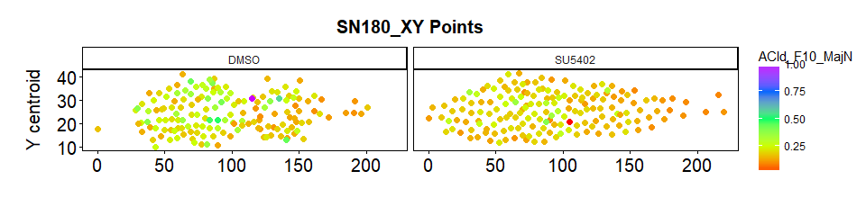

### 4.1.2 Apical Constriction only

Adapted ACI @ 10% of lateral height

[figure not shown]

Adapted ACI @ 15% of lateral height

[figure not shown]

| Obj | n |
| --- | --- |
| M_DMSO_P01_cells.csv | 157 |
| M_SU54_P17_cells.csv | 171 |

## 4.2 Value densities

Value densities @ 15% of lateral height

[figure not shown]

## 4.3 Mean values

[figure not shown]

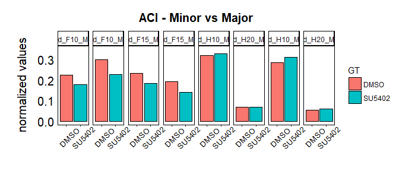

## 4.4 Constriction polarity

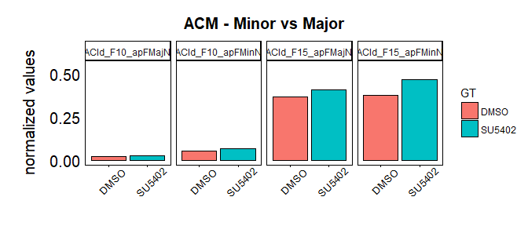

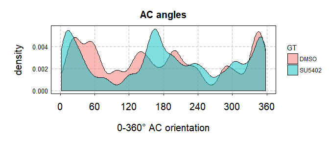

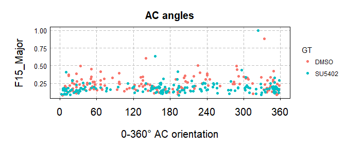

# 5 Discussion

Cells can be radially polarized<sup>7</sup>

# 6 Bibliography

1. Sawyer, J. M. *et al.* Apical constriction: A cell shape change that can drive morphogenesis. *Dev. Biol.* **341,** 5–19 (2010).

2. Lee, J.-y. & Harland, R. M. Actomyosin contractility and microtubules drive apical constriction in Xenopus bottle cells. *Dev. Biol.* **311,** 40–52 (2007).

3. Lecuit, T. & Lenne, P.-F. Cell surface mechanics and the control of cell shape, tissue patterns and morphogenesis. *Nat. Rev. Mol. Cell Biol.* **8,** 633–644 (2007).

4. Lee, C., Scherr, H. M. & Wallingford, J. B. Shroom family proteins regulate gamma-tubulin distribution and microtubule architecture during epithelial cell shape change. *Development* **134,** 1431–1441 (2007).

5. Harding, M. J. & Nechiporuk, A. V. Fgfr-Ras-MAPK signaling is required for apical constriction via apical positioning of Rho-associated kinase during mechanosensory organ formation. *Development* **139,** 3467–3467 (2012).

6. Harding, M. J. Regulation of Cell Shape During Development of the Nervous System. 1–97 (2013). doi:10.6083/M4VH5M4W

7. Coravos, J. S. & Martin, A. C. Apical Sarcomere-like Actomyosin Contracts Nonmuscle Drosophila Epithelial Cells. *Dev. Cell* 1–13 (2016). doi:10.1016/j.devcel.2016.09.023